# DeepLearning

## Introdução a Deep Learning com TensorFlow

Problema de Negócio:

Construir um modelo de Inteligência Artificial capaz de classificar imagens considerando 10 categorias: ['airplane', 'automobile', 'bird', 'cat', 'deer', 'dog', 'frog', 'horse', 'ship', 'truck']. Dada uma nova imagem de uma dessas categorias o modelo deve ser capaz de classificar e indicar o que é a imagem.

```python
# Instala o TF
!pip install -q tensorflow==2.12
```

```python
# Silencia mensagens do TF
%env TF_CPP_MIN_LOG_LEVEL=3
```

```
env: TF_CPP_MIN_LOG_LEVEL=3
```

```python
# Imports
import tensorflow as tf
from tensorflow.keras import datasets, layers, models
import matplotlib.pyplot as plt
import numpy as np
from PIL import Image
```

## Carregando os Dados

```python
# Carrega o dataset CIFAR-10
(imagens_treino, labels_treino), (imagens_teste, labels_teste) = datasets.cifar10.load_data()
```

```python
# Clases das imagens
nomes_classes = ['airplane', 'automobile', 'bird', 'cat', 'deer', 'dog', 'frog', 'horse', 'ship', 'truck']
```

## Pré-Processamento e Visualização das Imagens

```python
# Normaliza os valores dos pixels para que os dados fiquem na mesma escala
imagens_treino = imagens_treino / 255.0
imagens_teste = imagens_teste / 255.0
```

```python
# Função para exibir as imagens
def visualiza_imagens(images, labels):
    plt.figure(figsize = (10,10))
    for i in range(25):
        plt.subplot(5, 5, i+1)
        plt.xticks([])
        plt.yticks([])
        plt.grid(False)
        plt.imshow(images[i], cmap = plt.cm.binary)
        plt.xlabel(nomes_classes[labels[i][0]])
    plt.show()
```

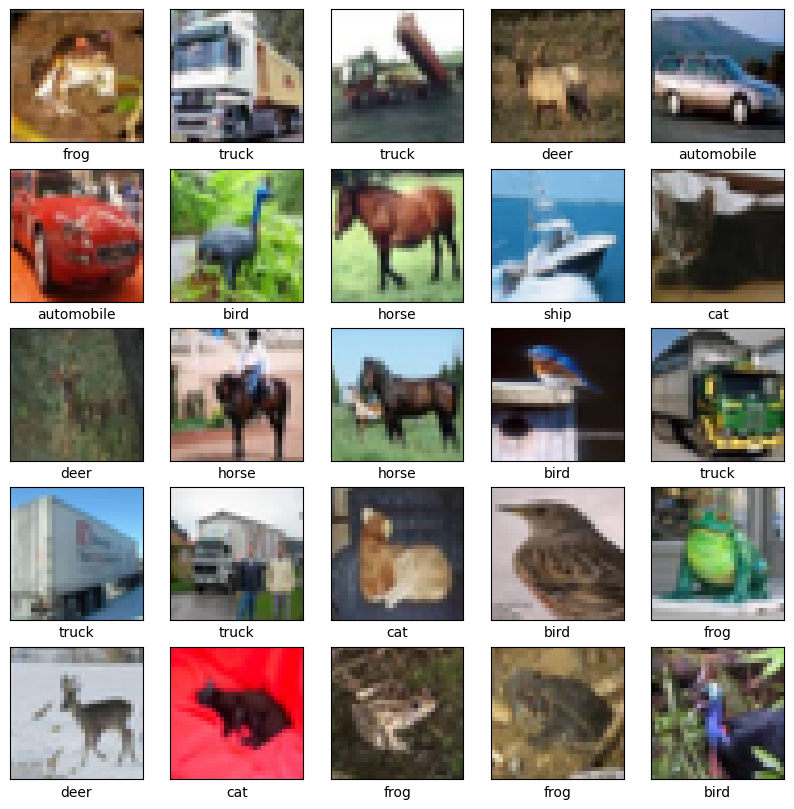

```python
# Executa a função
visualiza_imagens(imagens_treino, labels_treino)
```

```python
# Modelo

# Cria o objeto de sequência de camadas
modelo_dsa = models.Sequential()

# Adiciona o primeiro bloco de convolução e max pooling (camada de entrada)
modelo_dsa.add(layers.Conv2D(32, (3, 3), activation = 'relu', input_shape = (32, 32, 3)))
modelo_dsa.add(layers.MaxPooling2D((2, 2)))

# Adiciona o segundo bloco de convolução e max pooling (camada intermediária)
modelo_dsa.add(layers.Conv2D(64, (3, 3), activation = 'relu'))
modelo_dsa.add(layers.MaxPooling2D((2, 2)))

# Adiciona o terceiro bloco de convolução e max pooling (camada intermediária)
modelo_dsa.add(layers.Conv2D(64, (3, 3), activation = 'relu'))
modelo_dsa.add(layers.MaxPooling2D((2, 2)))
```

```python
# Adicionar camadas de classificação
modelo_dsa.add(layers.Flatten())
modelo_dsa.add(layers.Dense(64, activation = 'relu'))
modelo_dsa.add(layers.Dense(10, activation = 'softmax'))
```

```python
# Sumário do modelo
modelo_dsa.summary()
```

```
Model: "sequential"
_________________________________________________________________
 Layer (type)                Output Shape              Param #
=================================================================
 conv2d (Conv2D)             (None, 30, 30, 32)        896

 max_pooling2d (MaxPooling2D  (None, 15, 15, 32)       0
 )

 conv2d_1 (Conv2D)           (None, 13, 13, 64)        18496

 max_pooling2d_1 (MaxPooling  (None, 6, 6, 64)         0
 2D)

 conv2d_2 (Conv2D)           (None, 4, 4, 64)          36928

 max_pooling2d_2 (MaxPooling  (None, 2, 2, 64)         0
 2D)

 flatten (Flatten)           (None, 256)               0

 dense (Dense)               (None, 64)                16448

 dense_1 (Dense)             (None, 10)                650

=================================================================
Total params: 73,418
Trainable params: 73,418
Non-trainable params: 0
_________________________________________________________________
```

```python
# Compilação do modelo
modelo_dsa.compile(optimizer = 'adam',
                   loss = 'sparse_categorical_crossentropy',
                   metrics = ['accuracy'])
```

```python
%%time
history = modelo_dsa.fit(imagens_treino,
                         labels_treino,
                         epochs = 10,
                         validation_data = (imagens_teste, labels_teste))
```

```
CPU times: total: 10min 48s
Wall time: 7min 7s
```

## Avaliação do Modelo

```python
# Avalia o modelo
erro_teste, acc_teste = modelo_dsa.evaluate(imagens_teste, labels_teste, verbose = 2)
```

```
313/313 - 2s - loss: 0.8359 - accuracy: 0.7155 - 2s/epoch - 5ms/step
```

```python
print('\nAcurácia com Dados de Teste:', acc_teste)
```

```
Acurácia com Dados de Teste: 0.715499997138977
```

## Deploy do Modelo

```python
# Carrega uma nova imagem
nova_imagem = Image.open("dados/nova_imagem.jpg")
```

```python
# Dimensões da imagem (em pixels)
nova_imagem.size
```

```
(1919, 1199)
```

```python
# Obtém largura e altura da imagem
largura = nova_imagem.width
altura = nova_imagem.height
```

```python
print("A largura da imagem é: ", largura)
print("A altura da imagem é: ", altura)
```

```
A largura da imagem é:  1919
A altura da imagem é:  1199
```

```python
# Redimensiona para 32x32 pixels
nova_imagem = nova_imagem.resize((32, 32))
```

```python
# Exibir a imagem
plt.figure(figsize = (1,1))
plt.imshow(nova_imagem)
plt.xticks([])
plt.yticks([])
plt.show()
```

[output not shown]

```python
# Converte a imagem para um array NumPy e normaliza
nova_imagem_array = np.array(nova_imagem) / 255.0
```

```python
# Expande a dimensão do array para que ele tenha o formato (1, 32, 32, 3)
nova_imagem_array = np.expand_dims(nova_imagem_array, axis = 0)
```

```python
# Previsões
previsoes = modelo_dsa.predict(nova_imagem_array)
```

```python
print(previsoes)
```

```
[[2.6564654e-05 9.9211919e-01 1.6818817e-04 1.1935845e-05 4.9230175e-07
  9.1834845e-06 1.5982775e-03 5.0112972e-06 1.2739358e-05 6.0483506e-03]]
```

```python
# Obtém a classe com maior probabilidade e o nome da classe
classe_prevista = np.argmax(previsoes)
nome_classe_prevista = nomes_classes[classe_prevista]
```

```python
print("A nova imagem foi classificada como:", nome_classe_prevista)
```

```
A nova imagem foi classificada como: automobile
```

### Conclusão

Ao longo deste projeto, desenvolvi um modelo de classificação de imagens utilizando Deep Learning com TensorFlow. O modelo foi treinado e testado no dataset CIFAR-10, alcançando uma acurácia de 71,55% nos dados de teste. Utilizando uma rede neural convolucional, consegui identificar e classificar imagens em 10 categorias distintas, como 'airplane', 'automobile', 'bird', entre outras.

Este projeto serve como uma base sólida para aplicações futuras em visão computacional, mostrando o potencial do Deep Learning para resolver problemas complexos de classificação de imagens. Pretendo expandir este trabalho para outros tipos de datasets ou para tarefas mais desafiadoras, como a detecção de objetos ou a segmentação de imgens.